# hw01-5072

Weiting

2018年9月20日

> The data frame we are going to explore today is nba_draft_2015 (Projecting The Top 50 Players In The 2015 NBA Draft Class).

For what NBA stands for, see the footnote[^1] .

nba_draft_2015 from fivethrityeight is basically the raw data behind the story [“Projecting The Top 50 Players In The 2015 NBA Draft Class”](https://fivethirtyeight.com/features/projecting-the-top-50-players-in-the-2015-nba-draft-class/). An analysis using this data was contributed by G. Elliott Morris as a [package vignette](http://fivethirtyeight-r.netlify.com/articles/nba.html).

It is a data frame with 1090 rows representing National Basketball Association players/prospects and 9 variables. Here we can find some descriptions about the variables.

```
##   variable_name                                 variable_description
## 1        player                                          Player name
## 2      position                                The player's position
## 3            id                     The player's identification code
## 4    draft_year   The year the player was eligible for the NBA draft
## 5 projected_spm projected statistical -/+ over yrs 2-5 of NBA career
## 6     superstar          Probability of becoming a superstar player
## 7       starter    Probability of becoming a starting-caliber player
## 8   role_player                Probability of becoming a role player
## 9          bust                       Probability of becoming a bust
```

### Here is a summary of the data frame:

```
##     player            position              id              draft_year
##  Length:1090        Length:1090        Length:1090        Min.   :2001
##  Class :character   Class :character   Class :character   1st Qu.:2005
##  Mode  :character   Mode  :character   Mode  :character   Median :2009
##                                                           Mean   :2008
##                                                           3rd Qu.:2012
##                                                           Max.   :2015
##  projected_spm       superstar            starter         role_player
##  Min.   :-1.6847   Min.   :0.0000000   Min.   :0.00426   Min.   :0.07613
##  1st Qu.:-1.2109   1st Qu.:0.0001052   1st Qu.:0.03510   1st Qu.:0.32285
##  Median :-1.0281   Median :0.0008274   Median :0.06702   Median :0.36811
##  Mean   :-0.8101   Mean   :0.0114125   Mean   :0.12401   Mean   :0.35572
##  3rd Qu.:-0.5639   3rd Qu.:0.0056225   3rd Qu.:0.18696   3rd Qu.:0.40371
##  Max.   : 1.7768   Max.   :0.1819789   Max.   :0.65572   Max.   :0.54387
##       bust
##  Min.   :0.1614
##  1st Qu.:0.4299
##  Median :0.5250
##  Mean   :0.5089
##  3rd Qu.:0.5964
##  Max.   :0.8263
```

### Here is an interactive and a non-interative table of the data frame:

|  | player | position | id | draft_year | projected_spm | superstar | starter | role_player | bust |
| --- | --- | --- | --- | --- | --- | --- | --- | --- | --- |
| 1 | Karl-Anthony Towns | C | karl-anthony-towns | 2015 | 1.030605703 | 0.134766667 | 0.427183333 | 0.163083333 | 0.274966667 |
| 2 | Justise Winslow | SF | justise-winslow | 2015 | 0.875328997 | 0.083528571 | 0.510904762 | 0.176766667 | 0.2288 |
| 3 | Stanley Johnson | SF | stanley-johnson | 2015 | 0.679493305 | 0.0678 | 0.423733333 | 0.2785 | 0.229966667 |
| 4 | Jahlil Okafor | C | jahlil-okafor | 2015 | 0.521661276 | 0.058716667 | 0.4099 | 0.235533333 | 0.29585 |
| 5 | D`Angelo Russell | PG | d-angelo-russell | 2015 | 0.511966664 | 0.152033333 | 0.342283333 | 0.096583333 | 0.4091 |
| 6 | Dakari Johnson | C | dakari-johnson | 2015 | 0.491787354 | 0.021340778 | 0.36754357 | 0.417571997 | 0.193543655 |
| 7 | Devin Booker | SG | 3-devin-booker | 2015 | 0.472577305 | 0.073366667 | 0.324466667 | 0.390166667 | 0.212 |
| 8 | Willie Cauley-Stein | C | willie-cauley-stein | 2015 | 0.351171383 | 0.047114455 | 0.405989863 | 0.243185719 | 0.303709963 |
| 9 | Rondae Hollis-Jefferson | SF | rondae-hollis-jefferson | 2015 | 0.311909198 | 0.014589784 | 0.368533143 | 0.392480667 | 0.224396406 |
| 10 | Trey Lyles | PF | trey-lyles | 2015 | 0.267509411 | 0.022385714 | 0.351328571 | 0.403052381 | 0.223233333 |

[output cut: 1080 more lines]

| player | position | id | draft_year | projected_spm | superstar | starter | role_player | bust |
| --- | --- | --- | --- | --- | --- | --- | --- | --- |
| Karl-Anthony Towns | C | karl-anthony-towns | 2015 | 1.0306057 | 0.1347667 | 0.4271833 | 0.1630833 | 0.2749667 |
| Justise Winslow | SF | justise-winslow | 2015 | 0.8753290 | 0.0835286 | 0.5109048 | 0.1767667 | 0.2288000 |
| Stanley Johnson | SF | stanley-johnson | 2015 | 0.6794933 | 0.0678000 | 0.4237333 | 0.2785000 | 0.2299667 |
| Jahlil Okafor | C | jahlil-okafor | 2015 | 0.5216613 | 0.0587167 | 0.4099000 | 0.2355333 | 0.2958500 |
| D`Angelo Russell | PG | d-angelo-russell | 2015 | 0.5119667 | 0.1520333 | 0.3422833 | 0.0965833 | 0.4091000 |
| Dakari Johnson | C | dakari-johnson | 2015 | 0.4917874 | 0.0213408 | 0.3675436 | 0.4175720 | 0.1935437 |
| Devin Booker | SG | 3-devin-booker | 2015 | 0.4725773 | 0.0733667 | 0.3244667 | 0.3901667 | 0.2120000 |
| Willie Cauley-Stein | C | willie-cauley-stein | 2015 | 0.3511714 | 0.0471145 | 0.4059899 | 0.2431857 | 0.3037100 |
| Rondae Hollis-Jefferson | SF | rondae-hollis-jefferson | 2015 | 0.3119092 | 0.0145898 | 0.3685331 | 0.3924807 | 0.2243964 |
| Trey Lyles | PF | trey-lyles | 2015 | 0.2675094 | 0.0223857 | 0.3513286 | 0.4030524 | 0.2232333 |
| Sam Dekker | SF | sam-dekker | 2015 | 0.2541649 | 0.0086920 | 0.3850039 | 0.3290536 | 0.2772505 |
| Kelly Oubre Jr. | SF | kelly-oubre-jr | 2015 | 0.2473102 | 0.0198333 | 0.3789833 | 0.3379667 | 0.2632167 |
| Tyus Jones | PG | tyus-jones | 2015 | 0.2435488 | 0.0272000 | 0.4145619 | 0.2844048 | 0.2738333 |
| Kevon Looney | PF | kevon-looney | 2015 | 0.2041732 | 0.0083000 | 0.3555667 | 0.3749167 | 0.2612167 |
| Myles Turner | PF | 2-myles-turner | 2015 | 0.0763813 | 0.0294167 | 0.3357976 | 0.3185167 | 0.3162690 |

### Equation:

In this data dataframe we can do some simple calculations. If we know the bust data (A person’s probability of becoming a bust), then the equation$Nonbust = 1 - bust$ would help us to know the a person’s probability of not becoming a bust.

### Plotting:

Here we could draw a histogram of players’ probability of becoming a bust.

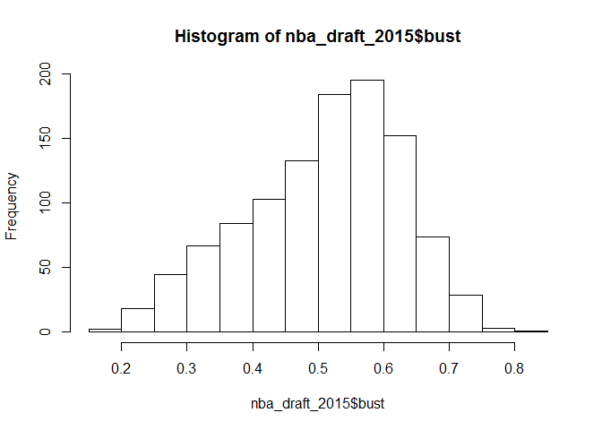

### By the way…

By the way, who is your favorite NBA star?

Mine is Stephen Curry:)

[figure not shown]

#### Now we have finish our exploration of the data frame. Great job!

[figure not shown]

[^1]: NBA stands for the National Basketball Association, a men’s professional basketball league in North America